# Week 8 Tutorial

### 2 Autocorrelation and Time Dependence

Working with observations across multiple time periods might introduce a new problem: **autocorrelation**.

Returning to the simulated data and the ACS examples, do you think autocorrelation might be a concern?

```
By construction, the dependent variable in the simulated data is not autocorrelated. However, in real life, profitability might be time dependent because the underlying drivers (brand strength, operational efficiency, market position) change slowly.

For the ACS data, it is likely that the percentage of self-employed individuals is correlated over time. Self-enployment is likley to be a persistent feature state-level economies and is constrained by imperfect labour market mobility.
```

Diagnosing autocorrelation requires a sufficiently large sample (usually T > 50-100). For simplicity, we will therefore switch to a new example.

Run the code below to simulate a dataset on the association between economic growth and unemployment.

```r
# Set seed for reproducibility
set.seed(123)

# time series
T <- 120  # 10 years of monthly data
dates <- seq.Date(from = as.Date("2015-01-01"),
                  by = "month",
                  length.out = T)

# economic growth with autocorrelation
growth <- numeric(T)
growth[1] <- rnorm(1, 0.2, 0.5)  # draws 1 value from N(0.2, 0.25)

for (t in 2:T) {
  growth[t] <- 0.6 * growth[t-1] + rnorm(1, 0, 0.4)
}

# unemployment as a function of economic growth and past unemployment
unemployment <- numeric(T)
unemployment[1] <- 6 + rnorm(1, 0, 0.3)

for (t in 2:T) {
  unemployment[t] <- 0.8 * unemployment[t-1] -
                     0.3 * growth[t] +
                     rnorm(1, 0, 0.2)
}

# dataframe
df_ts <- tibble(
  date = dates,
  economic_growth = growth,
  unemployment = unemployment
)
```

#### 2.1 Biased coefficients and SEs

Autocorrelation occurs when the **error terms in a regression model are correlated across observations**. Among other factors, this can result from omitting time-varying variables and misspecifying functional form and dynamics.

In our simulation, lagged coefficients are included in the output formula. This is typical for inert processes, such as macroeconomic trends.

By itself, omitting lagged coefficients produces **incorrect functional form** and leads to **biased estimates**. To see this, implement a naive OLS regression model that measures the association between economic growth and unemployment.

```r
# naive model
OLS_TS <- lm(unemployment ~ economic_growth, df_ts)
summary(OLS_TS)
```

```
##
## Call:
## lm(formula = unemployment ~ economic_growth, data = df_ts)
##
## Residuals:
##     Min      1Q  Median      3Q     Max
## -1.3697 -0.3801 -0.1606  0.1014  5.8417
##
## Coefficients:
##                 Estimate Std. Error t value Pr(>|t|)
## (Intercept)      0.17962    0.08385   2.142   0.0342 *
## economic_growth -0.17443    0.18903  -0.923   0.3580
## ---
## Signif. codes:  0 '***' 0.001 '**' 0.01 '*' 0.05 '.' 0.1 ' ' 1
##
## Residual standard error: 0.9168 on 118 degrees of freedom
## Multiple R-squared:  0.007164,   Adjusted R-squared:  -0.00125
## F-statistic: 0.8515 on 1 and 118 DF,  p-value: 0.358
```

Does the model correctly capture the known association between unemployment and economic growth?

```
According to the naive OLS, a single unit increase in economic growth produces a 0.17 decrease in unemployment. This is substantially different from the known by design association.
```

More importantely for statistical inference, omitted lagged variables create *autocorrelation in the error term**. This** biases the standard errors**. Because autocorrelation is left out of the regression equation, OLS residuals are time-dependent. Plot residuals from the naive OLS model.

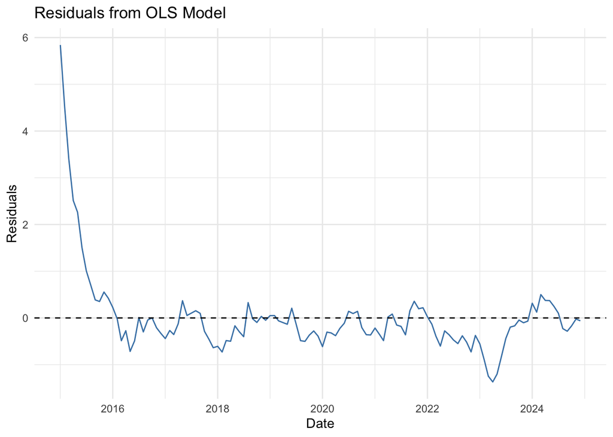

```r
df_ts$residuals <- resid(OLS_TS)

library(ggplot2)

ggplot(df_ts, aes(x = date, y = residuals)) +
  geom_line(color = "steelblue") +
  geom_hline(yintercept = 0, linetype = "dashed") +
  labs(title = "Residuals from OLS Model",
       x = "Date",
       y = "Residuals") +
  theme_minimal()
```

#### 2.2 Diagnosing Autocorrelation

To diagnose autocorrelation, we can use Autocorrelation Function (ACF) and Partial Autocorrelation Function (PACF) plots that measure correlation between a series and its lags, and formal tests.

First, use the ACF and the PACF to check for serial correlation in residuals. What is the interpretation of the plots?

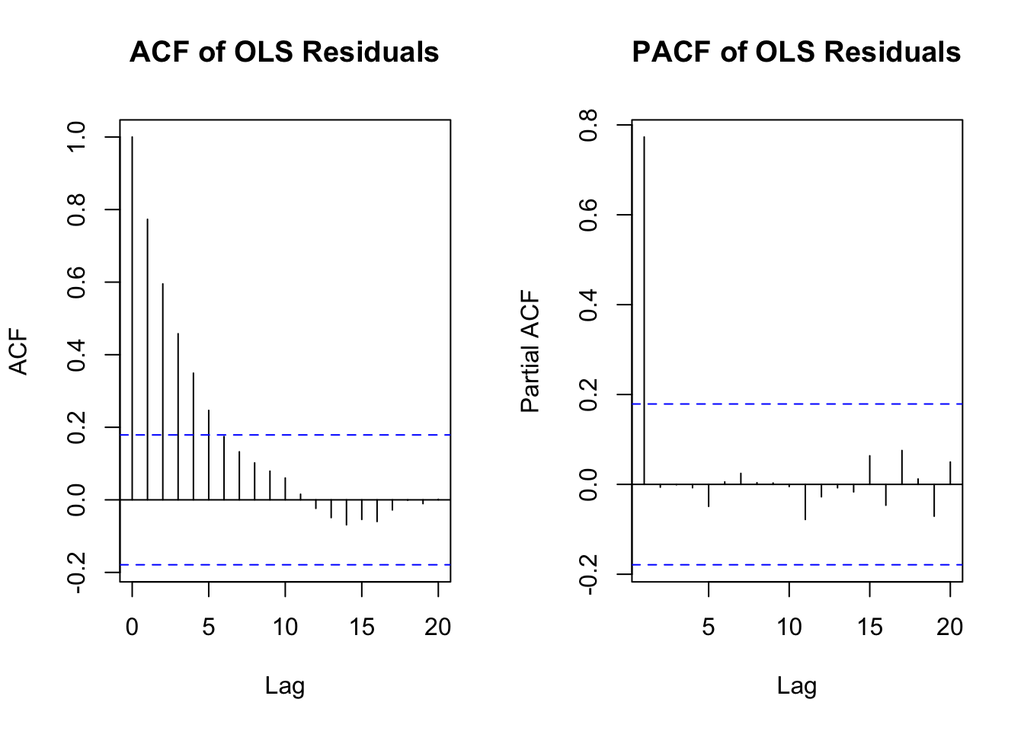

[output not shown]

```r
par(mfrow = c(1, 2))

acf(df_ts$residuals,
    main = "ACF of OLS Residuals")

pacf(df_ts$residuals,
    main = "PACF of OLS Residuals")
```

Alternatively, we can use the Durbin-Watson test for time dependence. Run the test and interpret the results.

```r
library(lmtest)
dwtest(OLS_TS)
```

```
##
##  Durbin-Watson test
##
## data:  OLS_TS
## DW = 0.10965, p-value < 2.2e-16
## alternative hypothesis: true autocorrelation is greater than 0
```

```
The p-valye of the Durbin-Watson test is below 0.05. We can therefore reject the null hypothesis that the true autocorrelation in the OLS model is 0.
```

#### 2.3 AR(1) Model

Time-series analysis is a complex field of econometrics and statistical inference. In practice, there is no single solution to autocorrelation, and the right model depends on the underlying assumptions about the data and the relationship.

For our example, a simple OLS with a lagged dependent variable will perform relatively well to get unbiased estimates. Because it uses a single lag of the dependent variable, this model is known as the **AR(1) model**.

Make a lag of the dependent variable and re-run the OLS specification. What is the interpretation of the coefficients?

```r
# make lag
df_ts <- df_ts %>% arrange(date)
df_ts$unemp_lag1 <- dplyr::lag(df_ts$unemployment, 1)
df_ts$economic_growth_lag1 <- dplyr::lag(df_ts$economic_growth, 1)

# drop first obs
df_ar <- df_ts %>% filter(!is.na(unemp_lag1))

# estimate
model_ar <- lm(unemployment ~ economic_growth + unemp_lag1, data = df_ar)
summary(model_ar)
```

```
##
## Call:
## lm(formula = unemployment ~ economic_growth + unemp_lag1, data = df_ar)
##
## Residuals:
##     Min      1Q  Median      3Q     Max
## -0.4010 -0.1305 -0.0219  0.1099  0.6241
##
## Coefficients:
##                  Estimate Std. Error t value Pr(>|t|)
## (Intercept)     -0.003183   0.018390  -0.173    0.863
## economic_growth -0.245812   0.040668  -6.044 1.87e-08 ***
## unemp_lag1       0.778154   0.019730  39.440  < 2e-16 ***
## ---
## Signif. codes:  0 '***' 0.001 '**' 0.01 '*' 0.05 '.' 0.1 ' ' 1
##
## Residual standard error: 0.1968 on 116 degrees of freedom
## Multiple R-squared:  0.9311, Adjusted R-squared:   0.93
## F-statistic: 784.4 on 2 and 116 DF,  p-value: < 2.2e-16
```

```r
# For robust SEs
library(lmtest)
library(sandwich)

coeftest(model_ar, vcov = NeweyWest(model_ar, lag = 4))
```

```
##
## t test of coefficients:
##
##                  Estimate Std. Error t value  Pr(>|t|)
## (Intercept)     -0.003183   0.014755 -0.2157    0.8296
## economic_growth -0.245812   0.045433 -5.4105 3.427e-07 ***
## unemp_lag1       0.778154   0.012665 61.4402 < 2.2e-16 ***
## ---
## Signif. codes:  0 '***' 0.001 '**' 0.01 '*' 0.05 '.' 0.1 ' ' 1
```

[output not shown]

Construct an ACF graph to check for autocorrelation in the residuals for the new model. What is the interpretation of the new ACF graph?

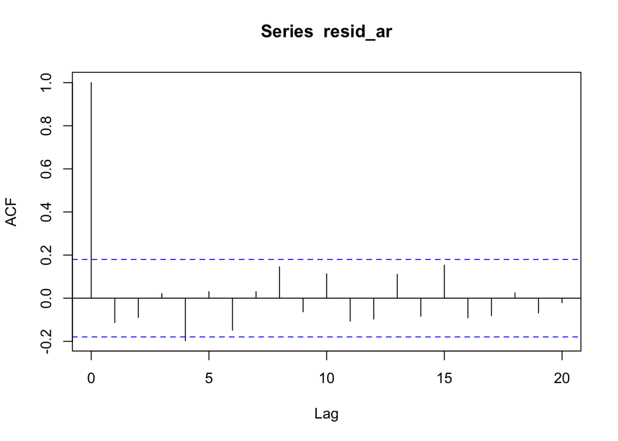

```
By including lagged terms in the AR(1) model, we remove time dependence in the residuals.
```

```r
# Residual ACF
resid_ar <- resid(model_ar)
acf(resid_ar)
```